# NYPD Shooting incident data analysis

5/21/2021

# Introduction

### purpose

In this article, I will **clean**, **visualize** and **analyze** [NYPD Shooting incident data](https://catalog.data.gov/dataset/nypd-shooting-incident-data-historic) to make it easier to see the trend of cumulative shooting incidents and murder cases per boroughs.

### contents

1. Data Cleaning
   1. Extract only the data needed for analysis
   2. Date format conversion
   3. Replace logical boolean data with integer type
   4. Add the number of shooting occurrences and the cumulative number of it as columns.
   5. Add the cumulative number of murders as a column.
2. Visualization
   1. Cumulative number of shooting events according to the flow of the date by borough
   2. Cumulative number of murder according to the flow of the date by borough
   3. Percentage of murders in total number of shootings by borough
3. Analysis
   - Compare the total number of shooting cases and murder ones *by borough*.
   - Calculate the percentage of murders in shootings *by borough*
     - `BROOKLYN`
     - `BRONX`
     - `QUEENS`
     - `MANHATTAN`
     - `STATEN ISLAND`
4. Model
   - Compare the actual trend of shooting incidents with the predictive linear model
5. Conclusion and Bias Identification
   - Conclude the project report
   - Identify personal bias and mitigation method

### 1.Data Cleaning

Data used in this project is every shooting incident data list occurred in NYC from Jan. 1, 2006 to Dec. 31, 2020.

**Data Importing**  
Here you can see the original dataset below.

```r
library(knitr)
library(tidyr)
library(tidyverse)
library(lubridate)
nypd <- read_csv("https://data.cityofnewyork.us/api/views/833y-fsy8/rows.csv?accessType=DOWNLOAD")
knitr::kable(head(nypd))
```

| INCIDENT_KEY | OCCUR_DATE | OCCUR_TIME | BORO | PRECINCT | JURISDICTION_CODE | LOCATION_DESC | STATISTICAL_MURDER_FLAG | PERP_AGE_GROUP | PERP_SEX | PERP_RACE | VIC_AGE_GROUP | VIC_SEX | VIC_RACE | X_COORD_CD | Y_COORD_CD | Latitude | Longitude | Lon_Lat |
| --- | --- | --- | --- | --- | --- | --- | --- | --- | --- | --- | --- | --- | --- | --- | --- | --- | --- | --- |
| 201575314 | 08/23/2019 | 22:10:00 | QUEENS | 103 | 0 | NA | FALSE | NA | NA | NA | 25-44 | M | BLACK | 1037451 | 193561 | 40.69781 | -73.80814 | POINT (-73.80814071699996 40.697805308000056) |
| 205748546 | 11/27/2019 | 15:54:00 | BRONX | 40 | 0 | NA | FALSE | <18 | M | BLACK | 25-44 | F | BLACK | 1006789 | 237559 | 40.81870 | -73.91857 | POINT (-73.91857061799993 40.81869973000005) |
| 193118596 | 02/02/2019 | 19:40:00 | MANHATTAN | 23 | 0 | NA | FALSE | 18-24 | M | WHITE HISPANIC | 18-24 | M | BLACK HISPANIC | 999347 | 227795 | 40.79192 | -73.94548 | POINT (-73.94547965999999 40.791916091000076) |
| 204192600 | 10/24/2019 | 00:52:00 | STATEN ISLAND | 121 | 0 | PVT HOUSE | TRUE | 25-44 | M | BLACK | 25-44 | F | BLACK | 938149 | 171781 | 40.63806 | -74.16611 | POINT (-74.16610830199996 40.63806398200006) |
| 201483468 | 08/22/2019 | 18:03:00 | BRONX | 46 | 0 | NA | FALSE | 25-44 | M | BLACK HISPANIC | 18-24 | M | BLACK | 1008224 | 250621 | 40.85455 | -73.91334 | POINT (-73.91333944399999 40.85454734900003) |
| 198255460 | 06/07/2019 | 17:50:00 | BROOKLYN | 73 | 0 | NA | FALSE | 45-64 | M | WHITE HISPANIC | 25-44 | M | BLACK | 1009650 | 186966 | 40.67983 | -73.90843 | POINT (-73.90842523899994 40.67982701600005) |

**Data cleaning**  
Date format was converted for easier reading and I replaced logical boolean data, ‘STATISTICAL_MURDER_FLAG’ with integer type like ‘0’ for FALSE and ‘1’ for TRUE. And I added the number of shooting occurrences and the cumulative number of it as columns with the names of ‘shooting’ and ‘cumshooting’. Also a column, ‘cummurder’, was added for the cumulative number of murders.

```r
library(dplyr)
library(ggplot2)


# select only needed data
nypd_test <- drop_na(nypd) %>%
  select(-c(INCIDENT_KEY, LOCATION_DESC, X_COORD_CD, Y_COORD_CD, Latitude, Longitude, Lon_Lat, JURISDICTION_CODE, OCCUR_TIME))

# change the date type
nypd_test <- nypd_test %>%
mutate(OCCUR_DATE = mdy(OCCUR_DATE))

#change logical boolean into int.
nypd_test$STATISTICAL_MURDER_FLAG [nypd_test$STATISTICAL_MURDER_FLAG == "TRUE"] <- 1
nypd_test$STATISTICAL_MURDER_FLAG [nypd_test$STATISTICAL_MURDER_FLAG == "FALSE"] <- 0



nypd_murder_boro <- nypd_test %>%
     group_by(BORO) %>%
#     summarize(STATISTICAL_MURDER_FLAG = sum(STATISTICAL_MURDER_FLAG)) %>%
     select(BORO, OCCUR_DATE, STATISTICAL_MURDER_FLAG) %>%
     ungroup()

nypd_murder_boro_1 <- nypd_murder_boro %>%
     group_by(BORO, OCCUR_DATE) %>%
     summarize(STATISTICAL_MURDER_FLAG = STATISTICAL_MURDER_FLAG) %>%
     select(BORO, OCCUR_DATE, STATISTICAL_MURDER_FLAG) %>%
     ungroup()
# add new columns
nypd_murder_boro_1$cummurder <- ave(nypd_murder_boro_1$STATISTICAL_MURDER_FLAG, nypd_murder_boro_1$BORO, FUN = cumsum)

nypd_murder_boro_1['shooting'] = 1

nypd_murder_boro_1$cumshooting <- ave(nypd_murder_boro_1$shooting, nypd_murder_boro_1$BORO, FUN = cumsum)

nypd_murder_boro_1$murderpercent <- with(nypd_murder_boro_1, cummurder/cumshooting *100)
# show the data that will be used for analysis
knitr::kable(head(nypd_murder_boro_1))
```

| BORO | OCCUR_DATE | STATISTICAL_MURDER_FLAG | cummurder | shooting | cumshooting | murderpercent |
| --- | --- | --- | --- | --- | --- | --- |
| BRONX | 2006-01-01 | 0 | 0 | 1 | 1 | 0 |
| BRONX | 2006-01-01 | 0 | 0 | 1 | 2 | 0 |
| BRONX | 2006-01-04 | 0 | 0 | 1 | 3 | 0 |
| BRONX | 2006-01-05 | 0 | 0 | 1 | 4 | 0 |
| BRONX | 2006-01-06 | 0 | 0 | 1 | 5 | 0 |
| BRONX | 2006-01-06 | 0 | 0 | 1 | 6 | 0 |

### 2. Visualization

Here comes three graphs. The first two shows the cumulative number of murder and of shooting events according to the flow of the date by borough. And the rest shows the percentage of murders in total number of shootings by borough.

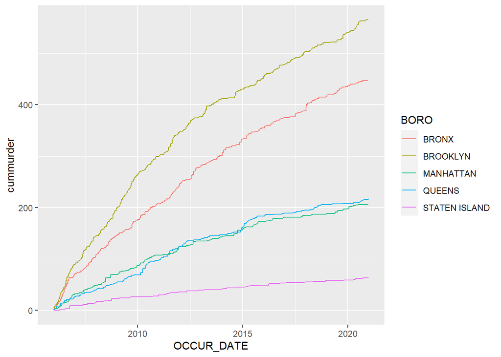

```r
#Visualization

nypd_murder_boro_1 %>%
  ggplot(aes(x = OCCUR_DATE, y=cummurder, group=BORO, color=BORO))+
  geom_line()
```

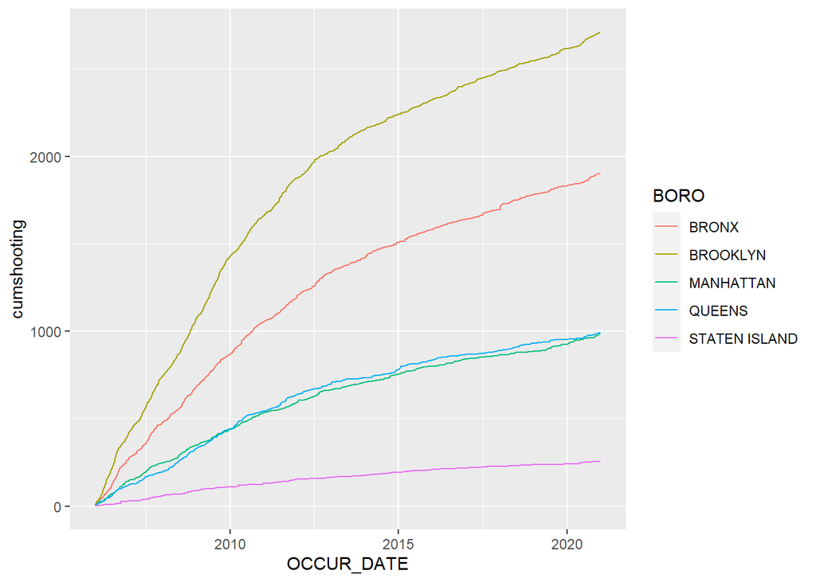

```r
nypd_murder_boro_1 %>%
  ggplot(aes(x = OCCUR_DATE, y=cumshooting, group=BORO, color=BORO))+
  geom_line()
```

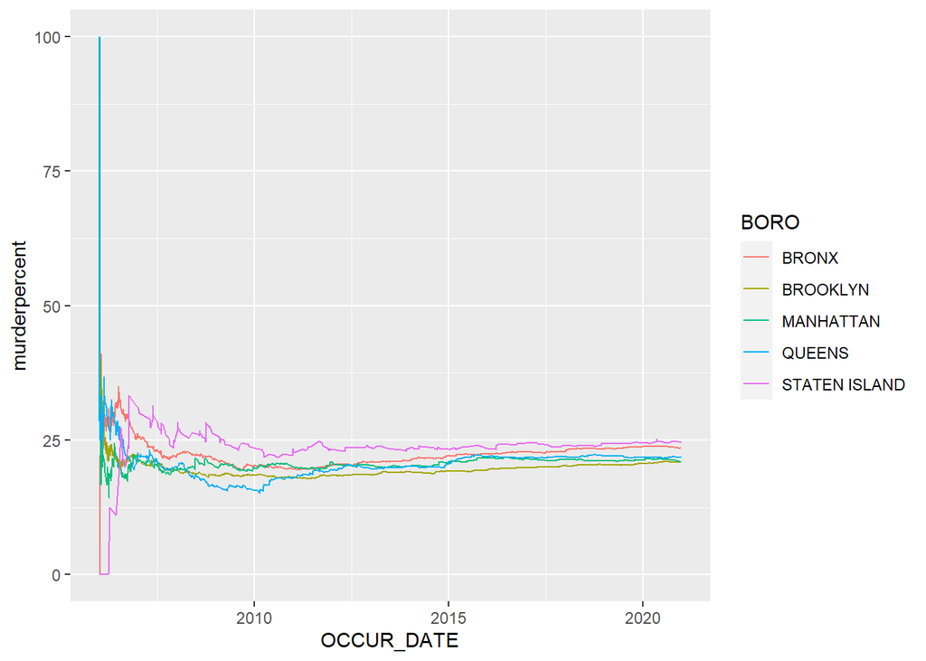

```r
nypd_murder_boro_1 %>%
  ggplot(aes(x = OCCUR_DATE, y=murderpercent, group=BORO, color=BORO))+
  geom_line()
```

### 3. Analysis

Comparing the total number of shooting cases and murder ones by borough I calculated the percentage of murders in shootings and found that in STATEN ISLAND the total number of shootings is the lowest, but the proportion of deaths from shootings is the highest.

```r
# analysis

aggregate(nypd_murder_boro_1$STATISTICAL_MURDER_FLAG, by=list(BORO = nypd_murder_boro_1$BORO), FUN=sum)
```

```
##            BORO   x
## 1         BRONX 448
## 2      BROOKLYN 565
## 3     MANHATTAN 206
## 4        QUEENS 217
## 5 STATEN ISLAND  63
```

```r
aggregate(nypd_murder_boro_1$shooting, by=list(BORO = nypd_murder_boro_1$BORO), FUN=sum)
```

```
##            BORO    x
## 1         BRONX 1903
## 2      BROOKLYN 2709
## 3     MANHATTAN  983
## 4        QUEENS  992
## 5 STATEN ISLAND  256
```

```r
city <- "BRONX"
nypd_murder_boro_BRONX <- nypd_murder_boro_1 %>%
     filter(BORO == city) %>%
     group_by(BORO, OCCUR_DATE) %>%
     #summarize(STATISTICAL_MURDER_FLAG = STATISTICAL_MURDER_FLAG) %>%
     select(BORO, OCCUR_DATE, shooting, cumshooting, STATISTICAL_MURDER_FLAG, cummurder, murderpercent) %>%
     ungroup()
knitr::kable(tail(nypd_murder_boro_BRONX))
```

| BORO | OCCUR_DATE | shooting | cumshooting | STATISTICAL_MURDER_FLAG | cummurder | murderpercent |
| --- | --- | --- | --- | --- | --- | --- |
| BRONX | 2020-11-15 | 1 | 1898 | 0 | 447 | 23.55111 |
| BRONX | 2020-11-26 | 1 | 1899 | 0 | 447 | 23.53870 |
| BRONX | 2020-12-04 | 1 | 1900 | 0 | 447 | 23.52632 |
| BRONX | 2020-12-04 | 1 | 1901 | 0 | 447 | 23.51394 |
| BRONX | 2020-12-14 | 1 | 1902 | 1 | 448 | 23.55415 |
| BRONX | 2020-12-24 | 1 | 1903 | 0 | 448 | 23.54178 |

```r
city <- "BROOKLYN"
nypd_murder_boro_BROOKLYN <- nypd_murder_boro_1 %>%
     filter(BORO == city) %>%
     group_by(BORO, OCCUR_DATE) %>%
     #summarize(STATISTICAL_MURDER_FLAG = STATISTICAL_MURDER_FLAG) %>%
     select(BORO, OCCUR_DATE, shooting, cumshooting, STATISTICAL_MURDER_FLAG, cummurder, murderpercent) %>%
     ungroup()
knitr::kable(tail(nypd_murder_boro_BROOKLYN))
```

| BORO | OCCUR_DATE | shooting | cumshooting | STATISTICAL_MURDER_FLAG | cummurder | murderpercent |
| --- | --- | --- | --- | --- | --- | --- |
| BROOKLYN | 2020-12-07 | 1 | 2704 | 0 | 565 | 20.89497 |
| BROOKLYN | 2020-12-07 | 1 | 2705 | 0 | 565 | 20.88725 |
| BROOKLYN | 2020-12-07 | 1 | 2706 | 0 | 565 | 20.87953 |
| BROOKLYN | 2020-12-09 | 1 | 2707 | 0 | 565 | 20.87181 |
| BROOKLYN | 2020-12-11 | 1 | 2708 | 0 | 565 | 20.86411 |
| BROOKLYN | 2020-12-25 | 1 | 2709 | 0 | 565 | 20.85640 |

```r
city <- "STATEN ISLAND"
nypd_murder_boro_STATENISLAND <- nypd_murder_boro_1 %>%
     filter(BORO == city) %>%
     group_by(BORO, OCCUR_DATE) %>%
     #summarize(STATISTICAL_MURDER_FLAG = STATISTICAL_MURDER_FLAG) %>%
     select(BORO, OCCUR_DATE, shooting, cumshooting, STATISTICAL_MURDER_FLAG, cummurder, murderpercent) %>%
     ungroup()
knitr::kable(tail(nypd_murder_boro_STATENISLAND))
```

| BORO | OCCUR_DATE | shooting | cumshooting | STATISTICAL_MURDER_FLAG | cummurder | murderpercent |
| --- | --- | --- | --- | --- | --- | --- |
| STATEN ISLAND | 2020-06-23 | 1 | 251 | 0 | 62 | 24.70120 |
| STATEN ISLAND | 2020-07-13 | 1 | 252 | 0 | 62 | 24.60317 |
| STATEN ISLAND | 2020-08-31 | 1 | 253 | 0 | 62 | 24.50593 |
| STATEN ISLAND | 2020-09-27 | 1 | 254 | 1 | 63 | 24.80315 |
| STATEN ISLAND | 2020-11-27 | 1 | 255 | 0 | 63 | 24.70588 |
| STATEN ISLAND | 2020-12-27 | 1 | 256 | 0 | 63 | 24.60938 |

```r
city <- "MANHATTAN"
nypd_murder_boro_MANHATTAN <- nypd_murder_boro_1 %>%
     filter(BORO == city) %>%
     group_by(BORO, OCCUR_DATE) %>%
     #summarize(STATISTICAL_MURDER_FLAG = STATISTICAL_MURDER_FLAG) %>%
     select(BORO, OCCUR_DATE, shooting, cumshooting, STATISTICAL_MURDER_FLAG, cummurder, murderpercent) %>%
     ungroup()
knitr::kable(tail(nypd_murder_boro_MANHATTAN))
```

| BORO | OCCUR_DATE | shooting | cumshooting | STATISTICAL_MURDER_FLAG | cummurder | murderpercent |
| --- | --- | --- | --- | --- | --- | --- |
| MANHATTAN | 2020-11-26 | 1 | 978 | 0 | 206 | 21.06339 |
| MANHATTAN | 2020-12-03 | 1 | 979 | 0 | 206 | 21.04188 |
| MANHATTAN | 2020-12-03 | 1 | 980 | 0 | 206 | 21.02041 |
| MANHATTAN | 2020-12-04 | 1 | 981 | 0 | 206 | 20.99898 |
| MANHATTAN | 2020-12-09 | 1 | 982 | 0 | 206 | 20.97760 |
| MANHATTAN | 2020-12-25 | 1 | 983 | 0 | 206 | 20.95626 |

```r
city <- "QUEENS"
nypd_murder_boro_QUEENS <- nypd_murder_boro_1 %>%
     filter(BORO == city) %>%
     group_by(BORO, OCCUR_DATE) %>%
     #summarize(STATISTICAL_MURDER_FLAG = STATISTICAL_MURDER_FLAG) %>%
     select(BORO, OCCUR_DATE, shooting, cumshooting, STATISTICAL_MURDER_FLAG, cummurder, murderpercent) %>%
     ungroup()
knitr::kable(tail(nypd_murder_boro_QUEENS))
```

| BORO | OCCUR_DATE | shooting | cumshooting | STATISTICAL_MURDER_FLAG | cummurder | murderpercent |
| --- | --- | --- | --- | --- | --- | --- |
| QUEENS | 2020-11-05 | 1 | 987 | 0 | 216 | 21.88450 |
| QUEENS | 2020-11-05 | 1 | 988 | 0 | 216 | 21.86235 |
| QUEENS | 2020-11-30 | 1 | 989 | 0 | 216 | 21.84024 |
| QUEENS | 2020-12-20 | 1 | 990 | 0 | 216 | 21.81818 |
| QUEENS | 2020-12-21 | 1 | 991 | 0 | 216 | 21.79617 |
| QUEENS | 2020-12-21 | 1 | 992 | 1 | 217 | 21.87500 |

### 4. Model

I made a linear model to predict the shooting incident of boroughs and compared it to the actual trend of shooting incidents. In graph below, the blue line represents the actual trend of shooting incidents and the red does the predictive model prediction.

```r
# Modeling Data

mod <- lm(cumshooting ~ cummurder, data = nypd_murder_boro_1)
summary(mod)
```

```
##
## Call:
## lm(formula = cumshooting ~ cummurder, data = nypd_murder_boro_1)
##
## Residuals:
##     Min      1Q  Median      3Q     Max
## -344.44  -41.04   -6.85   52.37  205.41
##
## Coefficients:
##             Estimate Std. Error t value Pr(>|t|)
## (Intercept) 3.086018   1.911421   1.615    0.106
## cummurder   4.951257   0.008042 615.697   <2e-16 ***
## ---
## Signif. codes:  0 '***' 0.001 '**' 0.01 '*' 0.05 '.' 0.1 ' ' 1
##
## Residual standard error: 94.14 on 6841 degrees of freedom
## Multiple R-squared:  0.9823, Adjusted R-squared:  0.9823
## F-statistic: 3.791e+05 on 1 and 6841 DF,  p-value: < 2.2e-16
```

```r
nypd_murder_boro_1 %>% slice_min(cumshooting)
```

```
## # A tibble: 5 x 7
##   BORO  OCCUR_DATE STATISTICAL_MUR~ cummurder shooting cumshooting murderpercent
##   <chr> <date>                <dbl>     <dbl>    <dbl>       <dbl>         <dbl>
## 1 BRONX 2006-01-01                0         0        1           1             0
## 2 BROO~ 2006-01-02                1         1        1           1           100
## 3 MANH~ 2006-01-01                1         1        1           1           100
## 4 QUEE~ 2006-01-01                1         1        1           1           100
## 5 STAT~ 2006-01-02                0         0        1           1             0
```

```r
nypd_murder_boro_1 %>% slice_max(cumshooting)
```

```
## # A tibble: 1 x 7
##   BORO  OCCUR_DATE STATISTICAL_MUR~ cummurder shooting cumshooting murderpercent
##   <chr> <date>                <dbl>     <dbl>    <dbl>       <dbl>         <dbl>
## 1 BROO~ 2020-12-25                0       565        1        2709          20.9
```

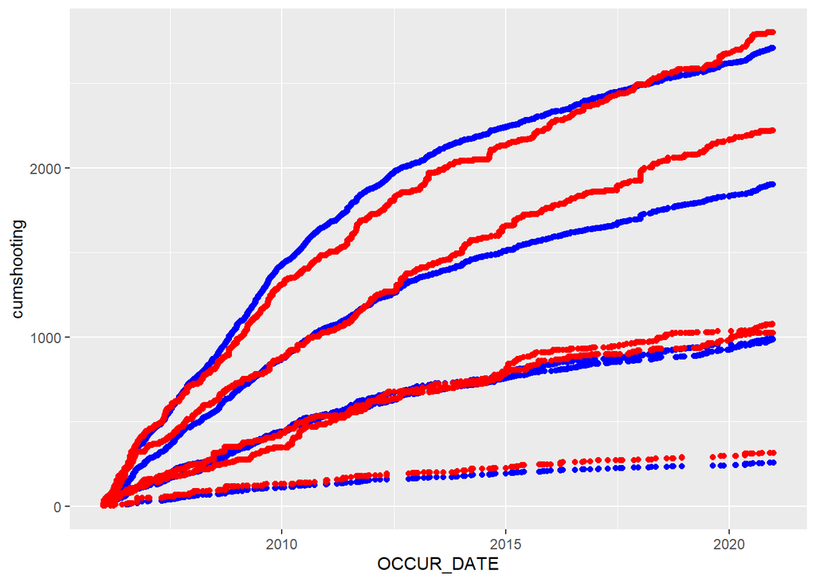

```r
x_grid <- seq(0, 3000)
new_df <- tibble(cumshooting = x_grid)

nypd_pred <- nypd_murder_boro_1 %>% mutate(pred = predict(mod))

# nypd_pred

nypd_pred %>% ggplot() +
  geom_point(aes(x = OCCUR_DATE, y=cumshooting), color= "blue")+
  geom_point(aes(x = OCCUR_DATE, y = pred), color = "red")
```

### 5. Conclusion and Bias Identification

The analysis shows that BROOKLYN is the place where the most shootings occurred in the data. However, STATEN ISLAND has the highest rate of deaths from shooting. If social policy is established based on this data, I think that prevention education for shootings should be approached in a different way in BROOKLYN and STATEN ISLAND.  
Born in a country in which possession of firearms itself is illegal, I have great fear of shooting itself and distrust of the society in which it is carried out. So, rather than seeing and understanding the data of citizens who can legally own firearms as an important part of society and thinking about countermeasures, the fact that there are many gunshots is just bad. However, while doing science, it has changed that I try to accept the phenomenon itself and recognize the value of research. Not making judgments about certain facts but trying to accept and understand the phenomenon in a neutral way is a way for me to step into a bigger world, and for our society to make the rules fairer.